# Optimization II

James M. Flegal

## Agenda

- Optimization with `optim()` and `nls()`
- Optimization under constraints
- Lagrange multipliers
- Penalized optimization
- Statistical uses of penalized optimization

## Optimization in R: optim()

`optim(par, fn, gr, method, control, hessian)`

- `fn`: function to be minimized; mandatory
- `par`: initial parameter guess; mandatory
- `gr`: gradient function; only needed for some methods
- `method`: defaults to a gradient-free method (``Nedler-Mead''), could be BFGS (Newton-ish)
- `control`: optional list of control settings
- (maximum iterations, scaling, tolerance for convergence, etc.)
- `hessian`: should the final Hessian be returned? default FALSE

Return contains the location (`$par`) and the value (`$val`) of the optimum, diagnostics, possibly `$hessian`

## Optimization in R: optim()

```r
gmp <- read.table("gmp.dat")
gmp$pop <- gmp$gmp/gmp$pcgmp
library(numDeriv)
mse <- function(theta) {
  mean((gmp$pcgmp - theta[1]*gmp$pop^theta[2])^2)
  }
grad.mse <- function(theta) { grad(func=mse,x=theta) }
theta0=c(5000,0.15)
fit1 <- optim(theta0,mse,grad.mse,method="BFGS",hessian=TRUE)
```

## Optimization in R: optim()

fit1: Newton-ish BFGS method

```r
fit1[1:3]
```

```
## $par
## [1] 6493.2563739    0.1276921
##
## $value
## [1] 61853983
##
## $counts
## function gradient
##       63       11
```

## Optimization in R: optim()

fit1: Newton-ish BFGS method

```r
fit1[4:6]
```

```
## $convergence
## [1] 0
##
## $message
## NULL
##
## $hessian
##              [,1]         [,2]
## [1,]      52.5021      4422071
## [2,] 4422071.3594 375729087979
```

## Optimization in R: nls()

- `optim` is a general-purpose optimizer
- `nlm` is another general-purpose optimizer; nonlinear least squares
- Try them both if one doesn't work

## Optimization in R: nls()

```r
nls(formula, data, start, control, [[many other options]])
```

- `formula`: Mathematical expression with response variable, predictor variable(s), and unknown parameter(s)
- `data`: Data frame with variable names matching `formula`
- `start`: Guess at parameters (optional)
- `control`: Like with `optim` (optional)

Returns an `nls` object, with fitted values, prediction methods, etc. The default optimization is a version of Newton's method.

## Optimization in R: nls()

fit2: Fitting the Same Model with nls()

```r
fit2 <- nls(pcgmp~y0*pop^a,data=gmp,start=list(y0=5000,a=0.1))
summary(fit2)
```

```
##
## Formula: pcgmp ~ y0 * pop^a
##
## Parameters:
##     Estimate Std. Error t value Pr(>|t|)
## y0 6.494e+03  8.565e+02   7.582 2.87e-13 ***
## a  1.277e-01  1.012e-02  12.612  < 2e-16 ***
## ---
## Signif. codes:  0 '***' 0.001 '**' 0.01 '*' 0.05 '.' 0.1 ' ' 1
##
## Residual standard error: 7886 on 364 degrees of freedom
##
## Number of iterations to convergence: 5
## Achieved convergence tolerance: 1.819e-07
```

## Optimization in R: nls()

fit2: Fitting the Same Model with nls()

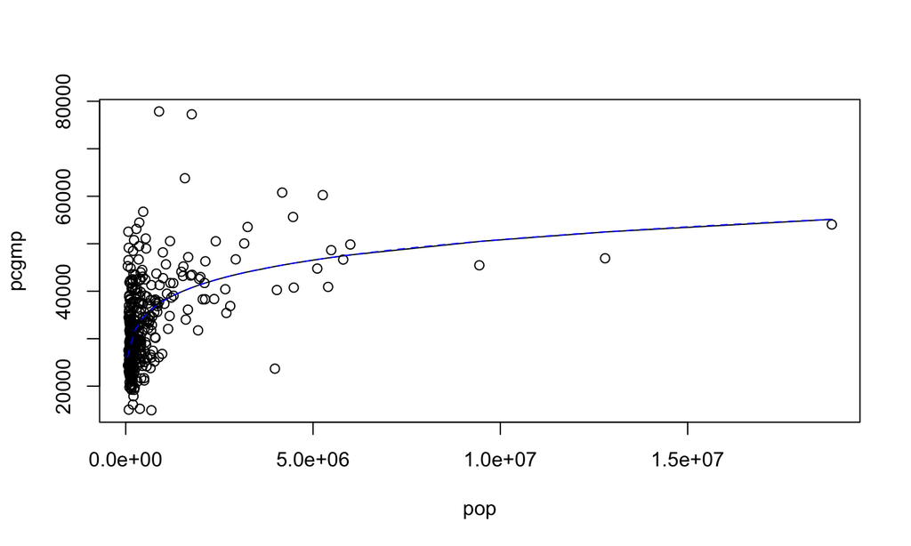

```r
plot(pcgmp~pop,data=gmp)
pop.order <- order(gmp$pop)
lines(gmp$pop[pop.order],fitted(fit2)[pop.order])
curve(fit1$par[1]*x^fit1$par[2],add=TRUE,lty="dashed",col="blue")
```

## Example: Multinomial

Roll dice $n$ times; $n_1, \ldots n_6$ count the outcomes

Likelihood and log-likelihood:

$$\begin{eqnarray*}
L(\theta_1,\theta_2,\theta_3,\theta_4,\theta_5,\theta_6) & = & \frac{n!}{n_1! n_2! n_3! n_4! n_5! n_6!}\prod_{i=1}^{6}{\theta_i^{n_i}}\\
\ell(\theta_1,\theta_2,\theta_3,\theta_4,\theta_5,\theta_6) & = & \log{\frac{n!}{n_1! n_2! n_3! n_4! n_5! n_6!}} + \sum_{i=1}^{6}{n_i\log{\theta_i}}
\end{eqnarray*}$$

Optimize by taking the derivative and setting to zero:

$$\begin{eqnarray*}
\frac{\partial \ell}{\partial \theta_1} & = & \frac{n_1}{\theta_1} = 0\\
\therefore \theta_1 & =& \infty
\end{eqnarray*}$$

## Example: Multinomial

We forgot that $\sum_{i=1}^{6}{\theta_i}=1$

We could use the constraint to eliminate one of the variables

$$\theta_6 = 1 - \sum_{i=1}^{5}{\theta_i}$$

Then solve the equations

$$\frac{\partial \ell}{\partial \theta_i} = \frac{n_1}{\theta_i} -\frac{n_6}{1-\sum_{j=1}^{5}{\theta_j}} = 0$$

BUT eliminating a variable with the constraint is usually messy

## Lagrange multipliers

$$g(\theta) = c ~ \Leftrightarrow ~ g(\theta)-c=0$$

**Lagrangian**:

$$\mathcal{L}(\theta,\lambda) = f(\theta) - \lambda(g(\theta)-c)$$

$= f$ when the constraint is satisfied

Now do *unconstrained* minimization over $\theta$ and $\lambda$:

$$\begin{eqnarray*}
{\left.\nabla_{\theta}\mathcal{L}\right|}_{\theta^*,\lambda^*} & = & \nabla f(\theta^*) - \lambda^*\nabla g(\theta^*) =0\\
{\left. \frac{\partial \mathcal{L}}{\partial \lambda}\right|}_{\theta^*,\lambda^*} & = & g(\theta^*) - c = 0
\end{eqnarray*}$$

optimizing **Lagrange multiplier** $\lambda$ enforces constraint

More constraints, more multipliers

## Lagrange multipliers

Try the dice again:

$$\begin{eqnarray*}
\mathcal{L} & = & \log{\frac{n!}{\prod_i{n_i!}}} + \sum_{i=1}^{6}{n_i\log{(\theta_i)}} - \lambda\left(\sum_{i=1}^{6}{\theta_i} - 1\right)\\
{\left.\frac{\partial\mathcal{L}}{\partial \theta_i}\right|}_{\theta_i=\theta^*_i} & = & \frac{n_i}{\theta^*_i} - \lambda^* = 0\\
\frac{n_i}{\lambda^*} & = & \theta^*_i\\
\sum_{i=1}^{6}{\frac{n_i}{\lambda^*}} & = & \sum_{i=1}^{6}{\theta^*_i} = 1\\
\lambda^* & =& \sum_{i=1}^{6}{n_i} ~ \Rightarrow \theta^*_i = \frac{n_i}{\sum_{i=1}^{6}{n_i}}
\end{eqnarray*}$$

## Lagrange multipliers

Constrained minimum value is generally higher than the unconstrained

Changing the constraint level $c$ changes $\theta^*$, $f(\theta^*)$

$$\begin{eqnarray*}
\frac{\partial f(\theta^*)}{\partial c} & = & \frac{\partial \mathcal{L}(\theta^*,\lambda^*)}{\partial c}\\
& = & \left[\nabla f(\theta^*)-\lambda^*\nabla g(\theta^*)\right]\frac{\partial \theta^*}{\partial c} - \left[g(\theta^*)-c\right]\frac{\partial \lambda^*}{\partial c} + \lambda^* = \lambda^*
\end{eqnarray*}$$

$\lambda^* =$ Rate of change in optimal value as the constraint is relaxed

$\lambda^* =$ ``Shadow price'': How much would you pay for minute change in the level of the constraint

## Inequality Constraints

What about an *inequality* constraint?

$$h(\theta) \leq d ~ \Leftrightarrow ~ h(\theta) - d \leq 0$$

The region where the constraint is satisfied is the **feasible set**

*Roughly* two cases:

1. Unconstrained optimum is inside the feasible set $\Rightarrow$ constraint is **inactive**
2. Optimum is outside feasible set; constraint **is active**, **binds** or **bites**; *constrained* optimum is usually on the boundary

Add a Lagrange multiplier; $\lambda \neq 0$ $\Leftrightarrow$ constraint binds

## Mathematical Programming

Older than computer programming…

Optimize $f(\theta)$ subject to $g(\theta) = c$ and $h(\theta) \leq d$

``Give us the best deal on $f$, keeping in mind that we've only got $d$ to spend, and the books have to balance''

Linear programming

1. $f$, $h$ both linear in $\theta$
2. $\theta^*$ always at a corner of the feasible set

## Example: Factory

Revenue: 13k per car, 27k per truck

Constraints:

$$\begin{eqnarray*}
40 * \mathrm{cars} + 60*\mathrm{trucks} & < & 1600 \mathrm{hours} \\
1 * \mathrm{cars}+ 3 * \mathrm{trucks} & < & 70 \mathrm{tons}
\end{eqnarray*}$$

Find the revenue-maximizing number of cars and trucks to produce

## Example: Factory

The feasible region:

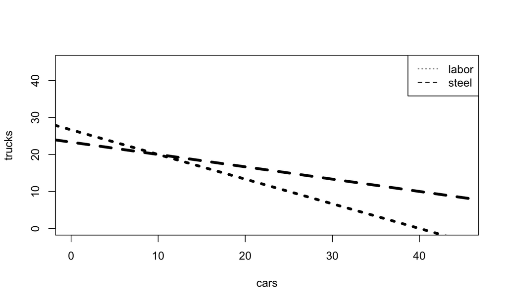

## Example: Factory

The feasible region, plus lines of equal profit

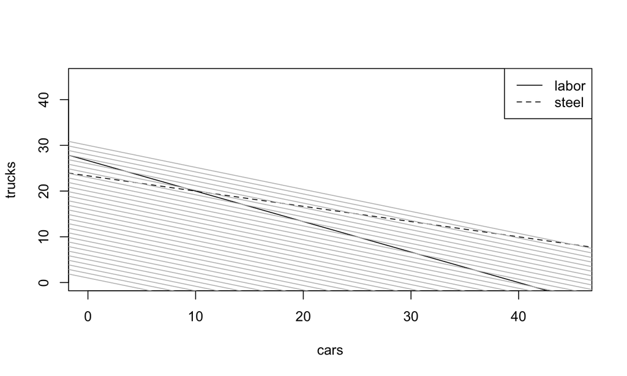

## More Complex Financial Problem

*Given*: expected returns $r_1, \ldots r_p$ among $p$ financial assets, their $p\times p$ matrix of variances and covariances $\Sigma$

*Find*: the portfolio shares $\theta_1, \ldots \theta_n$ which maximizes expected returns

*Such that*: total variance is below some limit, covariances with specific other stocks or portfolios are below some limit  
e.g., pension fund should not be too correlated with parent company

Expected returns $f(\theta) = r\cdot\theta$

Constraints: $\sum_{i=1}^{p}{\theta_i}=1$, $\theta_i \geq 0$ (unless you can short)  
Covariance constraints are linear in $\theta$  
Variance constraint is quadratic, over-all variance is $\theta^T \Sigma \theta$

## Barrier Methods

(a.k.a. "interior point", "central path", etc.)

Having constraints switch on and off abruptly is annoying, especially with gradient methods

Fix $\mu >0$ and try minimizing

$$f(\theta) - \mu\log{\left(d-h(\theta)\right)}$$
"pushes away" from the barrier — more and more weakly as $\mu \rightarrow 0$

## Barrier Methods

1. Initial $\theta$ in feasible set, initial $\mu$
2. While ((not too tired) and (making adequate progress))
   1. Minimize $f(\theta) - \mu\log{\left(d-h(\theta)\right)}$
   2. Reduce $\mu$
3. Return final $\theta$

## R implementation

`constrOptim` implements the barrier method

Try this:

```r
factory <- matrix(c(40,1,60,3),nrow=2,
  dimnames=list(c("labor","steel"),c("car","truck")))
available <- c(1600,70); names(available) <- rownames(factory)
prices <- c(car=13,truck=27)
revenue <- function(output) { return(-output %*% prices) }
plan <- constrOptim(theta=c(5,5),f=revenue,grad=NULL,
  ui=-factory,ci=-available,method="Nelder-Mead")
plan$par
```

```
## [1]  9.999896 20.000035
```

`constrOptim` only works with constraints like $\mathbf{u}\theta \geq c$, so minus signs

## Constraints vs. Penalties

$$\DeclareMathOperator*{\argmax}{argmax}
\DeclareMathOperator*{\argmin}{argmin}
\argmin_{\theta : h(\theta) \leq d}{f(\theta)} ~ \Leftrightarrow \argmin_{\theta,\lambda}{f(\theta) - \lambda(h(\theta)-d)}$$

$d$ doesn't matter for doing the second minimization over $\theta$

We could just as well minimize

$$f(\theta) - \lambda h(\theta)$$

| Constrained optimization | Penalized optimization |
| --- | --- |
| Constraint level $d$ | Penalty factor $\lambda$ |

## Statistical applications of penalization

Mostly you've seen unpenalized estimates (least squares, maximum likelihood)

Lots of modern advanced methods rely on penalties

- For when the direct estimate is too unstable
- For handling high-dimensional cases
- For handling non-parametrics

## Ordinary least squares

No penalization; minimize MSE of linear function $\beta \cdot x$:

$$\hat{\beta} = \argmin_{\beta}{\frac{1}{n}\sum_{i=1}^{n}{(y_i - \beta\cdot x_i)^2}} = \argmin_{\beta}{MSE(\beta)}$$

Closed-form solution if we can invert matrices:

$$\hat{\beta} = (\mathbf{x}^T\mathbf{x})^{-1}\mathbf{x}^T\mathbf{y}$$

where $\mathbf{x}$ is the $n\times p$ matrix of $x$ vectors, and $\mathbf{y}$ is the $n\times 1$ matrix of $y$ values.

## Ridge regression

Now put a penalty on the *magnitude* of the coefficient vector:

$$\tilde{\beta} = \argmin_{\beta}{MSE(\beta) + \mu \sum_{j=1}^{p}{\beta_j^2}} = \argmin_{\beta}{MSE(\beta) + \mu \|\beta\|_2^2}$$

Penalizing $\beta$ this way makes the estimate more *stable*; especially useful for

- Lots of noise
- Collinear data ($\mathbf{x}$ not of "full rank")
- High-dimensional, $p > n$ data (which implies collinearity)

This is called **ridge regression**, or **Tikhonov regularization**

Closed form:

$$\tilde{\beta} = (\mathbf{x}^T\mathbf{x} + \mu I)^{-1}\mathbf{x}^T\mathbf{y}$$

## The Lasso

Put a penalty on the sum of coefficient's absolute values:

$$\beta^{\dagger} = \argmin_{\beta}{MSE(\beta) + \lambda \sum_{j=1}^{p}{|\beta_j|}} = \argmin_{\beta}{MSE(\beta) + \lambda\|\beta\|_1}$$

This is called **the lasso**

- Also stabilizes (like ridge)
- Also handles high-dimensional data (like ridge)
- Enforces **sparsity**: it likes to drive small coefficients exactly to 0

No closed form, but very efficient interior-point algorithms (e.g., `lars` package)

## Spline smoothing

"Spline smoothing": minimize MSE of a smooth, nonlinear function, plus a penalty on curvature:

$$\hat{f} = \argmin_{f}{\frac{1}{n}\sum_{i=1}^{n}{(y_i-f(x_i))^2} + \int{(f^{\prime\prime}(x))^2 dx}}$$

This fits smooth regressions without assuming any specific functional form

- Lets you check linear models
- Makes you wonder why you bother with linear models

Many different R implementations, starting with `smooth.spline`

## How Big a Penalty?

Rarely know the constraint level or the penalty factor $\lambda$ from on high

Lots of ways of picking, but often **cross-validation** works well

- Divide the data into parts
- For each value of $\lambda$, estimate the model on one part of the data
- See how well the models fit the other part of the data
- Use the $\lambda$ which extrapolates best on average

## Summary

- Start with pre-built code like `optim` or `nls`, implement your own as needed
- Use Lagrange multipliers to turn constrained optimization problems into unconstrained but penalized ones
  - Optimal multiplier values are the prices we'd pay to weaken the constraints
- The nature of the penalty term reflects the sort of constraint we put on the problem
  - Shrinkage
  - Sparsity
  - Smoothness

## Example: Lasso

```r
x <- matrix(rnorm(200),nrow=100)
y <- (x %*% c(2,1))+ rnorm(100,sd=0.05)
mse <- function(b1,b2) {mean((y- x %*% c(b1,b2))^2)}
coef.seq <- seq(from=-1,to=5,length.out=200)
m <- outer(coef.seq,coef.seq,Vectorize(mse))
l1 <- function(b1,b2) {abs(b1)+abs(b2)}
l1.levels <- outer(coef.seq,coef.seq,l1)
ols.coefs <- coefficients(lm(y~0+x))
```

## Example: Lasso

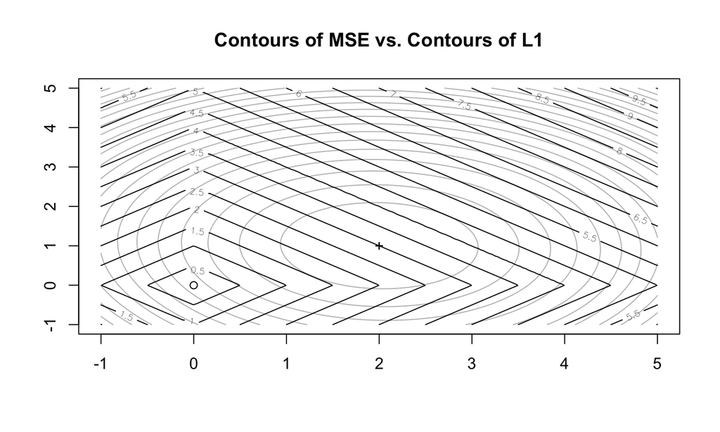

```r
contour(x=coef.seq,y=coef.seq,z=m,drawlabels=FALSE,nlevels=30,col="grey",
  main="Contours of MSE vs. Contours of L1")
contour(x=coef.seq,y=coef.seq,z=l1.levels,nlevels=20,add=TRUE)
points(x=ols.coefs[1],y=ols.coefs[2],pch="+")
points(0,0)
```

## Example: Lasso

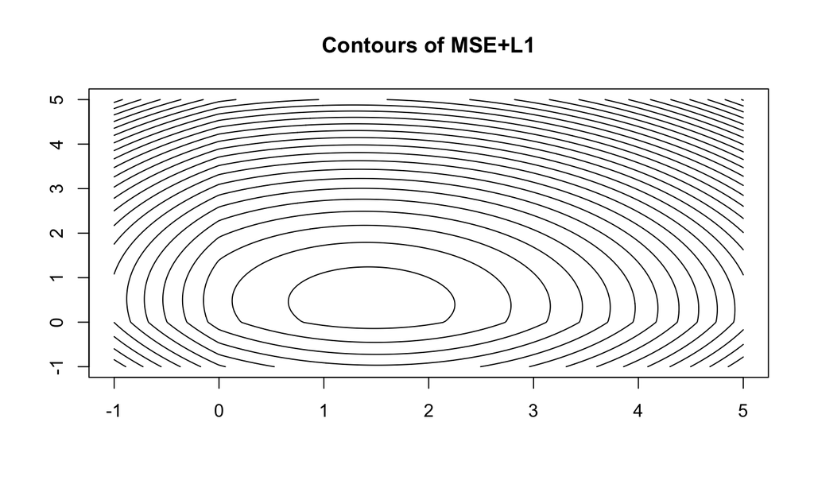

```r
contour(x=coef.seq,y=coef.seq,z=m+l1.levels,drawlabels=FALSE,nlevels=30,
  main="Contours of MSE+L1")
```

## Bonus: Writing Our Own gradient()

- Suppose we didn't know about the `numDeriv` package..
- Use the simplest possible method: change `x` by some amount, find the difference in `f`, take the slope  
  `method="simple"` option in `numDeriv::grad`
- Start with pseudo-code

```r
gradient <- function(f,x,deriv.steps) {
  # not real code
  evaluate the function at x and at x+deriv.steps
  take slopes to get partial derivatives
  return the vector of partial derivatives
}
```

## Bonus Example: gradient()

A naive implementation would use a `for` loop

```r
gradient <- function(f,x,deriv.steps,...) {
  p <- length(x)
  stopifnot(length(deriv.steps)==p)
  f.old <- f(x,...)
  gradient <- vector(length=p)
  for (coordinate in 1:p) {
   x.new <- x
   x.new[coordinate] <- x.new[coordinate]+deriv.steps[coordinate]
   f.new <- f(x.new,...)
   gradient[coordinate] <- (f.new - f.old)/deriv.steps[coordinate]
  }
  return(gradient)
}
```

Works, but it's so repetitive!

## Bonus Example: gradient()

Better: use matrix manipulation and `apply`

```r
gradient <- function(f,x,deriv.steps,...) {
  p <- length(x)
  stopifnot(length(deriv.steps)==p)
  x.new <- matrix(rep(x,times=p),nrow=p) + diag(deriv.steps,nrow=p)
  f.new <- apply(x.new,2,f,...)
  gradient <- (f.new - f(x,...))/deriv.steps
  return(gradient)
}
```

(clearer, and half as long)

- Presumes that `f` takes a vector and returns a single number
- Any extra arguments to `gradient` will get passed to `f`
- Check: Does this work when `f` is a function of a single number?

## Bonus Example: gradient()

- Acts badly if `f` is only defined on a limited domain and we ask for the gradient somewhere near a boundary
- Forces the user to choose `deriv.steps`
- Uses the same `deriv.steps` everywhere, imagine $f(x) = x^2\sin{x}$

… and so on through much of a first course in numerical analysis